# 498818_SDS496_HW8

Problem 1. Download the horse colic data set under Modules on Canvas. The data set measures different variables for horses with lesions in the digestive tract.

i. Split the data set into a training set and a test set. Fit a classification tree on the training set with only pulse and total.protein as predictors. Provide a plot of the classification tree.

```python
import pandas as pd

# Load the data
data = pd.read_csv('/Users/aidanashrafi/Downloads/horse-colic.csv')

# Select specific columns (columns 4 to 6, 16, 19, 20, 22, 23 in 1-based R index)
# Equivalent to 3, 4, 5, 15, 18, 19, 21, 22 in Python 0-based index
data = data.iloc[:, [3, 4, 5, 15, 18, 19, 21, 22]]

# Number of columns to process (excluding the 'outcome' column)
p = 7

# Impute missing values for the first p columns with the column mean
for j in range(p):  # Loop through columns 0 to 6 (first 7 columns)
    data.iloc[:, j].fillna(data.iloc[:, j].mean(), inplace=True)

# Remove rows where 'outcome' (the last column) is still missing
data = data[data.iloc[:, -1].notna()]

# Check non-null
data.info()
```

```
<class 'pandas.core.frame.DataFrame'>
Index: 299 entries, 0 to 299
Data columns (total 8 columns):
 #   Column                       Non-Null Count  Dtype
---  ------                       --------------  -----
 0   rectal temperature           299 non-null    float64
 1   pulse                        299 non-null    float64
 2   respiratory rate             299 non-null    float64
 3   nasogastric reflux PH        299 non-null    float64
 4   packed cell volume           299 non-null    float64
 5   total protein                299 non-null    float64
 6   abdomcentesis total protein  299 non-null    float64
 7   outcome                      299 non-null    float64
dtypes: float64(8)
memory usage: 21.0 KB
```

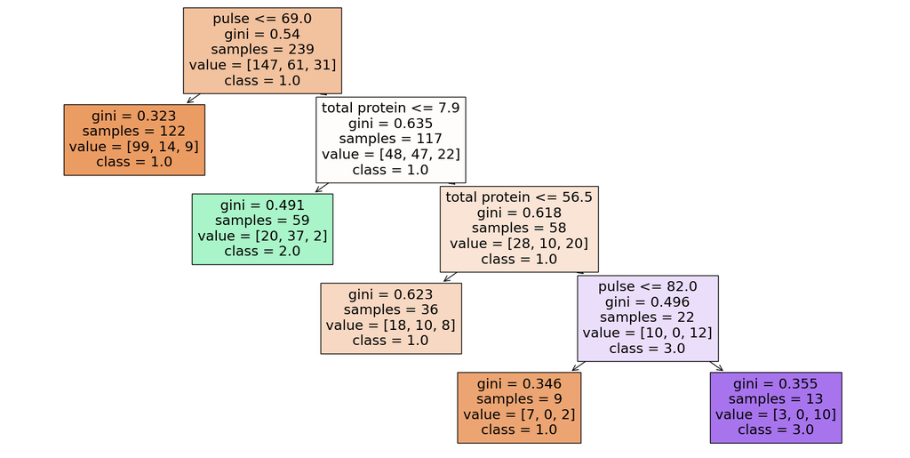

```python
import numpy as np
import matplotlib.pyplot as plt
from sklearn.model_selection import train_test_split
from sklearn.tree import DecisionTreeClassifier, plot_tree
from sklearn.metrics import confusion_matrix, accuracy_score

# Split the data into training and testing sets
train, test = train_test_split(data, test_size=0.2, random_state=0)

# Prepare the training data (using 'pulse' and 'total.protein' as predictors)
X_train = train[['pulse', 'total protein']]
y_train = train['outcome']
X_test = test[['pulse', 'total protein']]
y_test = test['outcome']

# Fit a Decision Tree model (used specific parameters that were in code from class)
model = DecisionTreeClassifier(max_depth=30, min_samples_split=20, min_samples_leaf=7, random_state=0, ccp_alpha=0.01)
tree = model.fit(X_train, y_train)

# Plot the classification tree
plt.figure(figsize=(20, 10))
plot_tree(tree, feature_names=['pulse', 'total protein'], class_names=model.classes_.astype(str), filled=True)
plt.show()
```

How many internal nodes, leaves and branches does it have? What form do the decision boundaries have for this classification tree? Calculate the confusion matrix and the misclassification rate on the test set.

```python
# Predict on the test set
y_pred = model.predict(X_test)

# Calculate and print the confusion matrix and misclassification rate
conf_matrix = confusion_matrix(y_test, y_pred)
misclassification_rate = 1 - accuracy_score(y_test, y_pred)

print("Confusion Matrix:")
print(conf_matrix)
print(f"Misclassification Rate: {misclassification_rate:.2f}")
num_leaves = model.get_n_leaves()
num_nodes = model.tree_.node_count
num_internal_nodes = num_nodes - num_leaves  # Exclude leaves to count internal nodes

print("Number of internal nodes:", num_internal_nodes)
print("Number of leaves:", num_leaves)
print("Total number of nodes (including leaves):", num_nodes)
```

```
Confusion Matrix:
[[24  5  2]
 [11  5  0]
 [ 9  3  1]]
Misclassification Rate: 0.50
Number of internal nodes: 4
Number of leaves: 5
Total number of nodes (including leaves): 9
```

There are 4 internal nodes, 5 leaves, and 8 branches. The decision boundaries for this classification tree are linear. The misclassification rate is 0.50.

ii. Fit a classification tree on the training set with all available predictors. Provide a plot of the classification tree. How many internal nodes, leaves and branches does it have? Calculate the confusion matrix and the misclassification rate on the test set. How does this classification tree compare against that in the previous part?

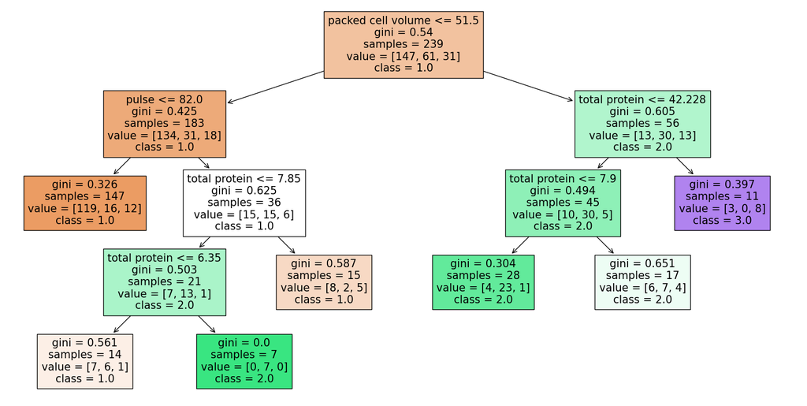

```python
X_train_all = train.drop(columns=['outcome'])  # All columns except 'outcome'
y_train_all = train['outcome']
X_test_all = test.drop(columns=['outcome'])  # All columns except 'outcome'
y_test_all = test['outcome']
# Fit a Decision Tree model using all predictors
model_all = DecisionTreeClassifier(max_depth=30, min_samples_split=20, min_samples_leaf=7, random_state=0, ccp_alpha=0.01)
full_tree = model_all.fit(X_train_all, y_train_all)

# Plot the classification tree
plt.figure(figsize=(20, 10))
plot_tree(full_tree, feature_names=X_train_all.columns, class_names=model_all.classes_.astype(str), filled=True)
plt.show()
```

How many internal nodes, leaves and branches does it have? Calculate the confusion matrix and the misclassification rate on the test set. How does this classification tree compare against that in the previous part?

```python
# Predict on the test set
y_pred_all = model_all.predict(X_test_all)

# Calculate and print the confusion matrix and misclassification rate
conf_matrix_all = confusion_matrix(y_test_all, y_pred_all)
misclassification_rate_all = 1 - accuracy_score(y_test_all, y_pred_all)

print("Confusion Matrix for all predictors:")
print(conf_matrix_all)
print(f"Misclassification Rate for all predictors: {misclassification_rate_all:.2f}")

# Print the number of internal nodes, leaves, and total nodes
num_leaves_all = model_all.get_n_leaves()
num_nodes_all = model_all.tree_.node_count
num_internal_nodes_all = num_nodes_all - num_leaves_all  # Exclude leaves to count internal nodes

print("Number of internal nodes (all predictors):", num_internal_nodes_all)
print("Number of leaves (all predictors):", num_leaves_all)
print("Total number of nodes (including leaves, all predictors):", num_nodes_all)
print("Number of branches (all predictors):", num_nodes_all - 1)  # Total nodes minus
```

```
Confusion Matrix for all predictors:
[[27  2  2]
 [ 9  7  0]
 [ 8  2  3]]
Misclassification Rate for all predictors: 0.38
Number of internal nodes (all predictors): 6
Number of leaves (all predictors): 7
Total number of nodes (including leaves, all predictors): 13
Number of branches (all predictors): 12
```

There are 6 internal nodes, 7 leaves, and 12 branches. The misclassification rate is 0.38. This classification tree is better than the previous part.

iii. Perform cost-complexity pruning on the classification tree in the previous part. Provide a plot of the pruned classification tree. How many internal nodes, leaves and branches are left? Which predictors appear to be most important for the classification of the outcome? Calculate the confusion matrix and the misclassification rate on the test set. How does this pruned classification tree compare against that in the previous part?

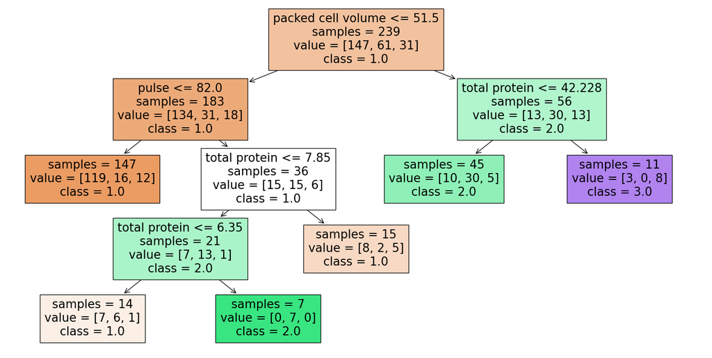

```python
from sklearn.model_selection import KFold, GridSearchCV
from sklearn.tree import DecisionTreeClassifier, plot_tree
import matplotlib.pyplot as plt

# Obtain the cost-complexity pruning path from the fitted model
ccp_path = full_tree.cost_complexity_pruning_path(X_train_all, y_train_all)
ccp_alphas = ccp_path.ccp_alphas  # Effective alphas

# Set up KFold cross-validation
kfold = KFold(10, shuffle=True, random_state=0)

# Use GridSearchCV to find the best alpha for pruning with an unfitted DecisionTreeClassifier
grid = GridSearchCV(full_tree, param_grid={'ccp_alpha': ccp_alphas},scoring='accuracy',refit=True,cv=kfold)

# Fit the GridSearchCV on the training data to find the best ccp_alpha
pruned = grid.fit(X_train_all, y_train_all)

# Get the best pruned tree from GridSearchCV
pruned_tree = pruned.best_estimator_

# Plot the pruned classification tree
plt.figure(figsize=(20, 10))
plot_tree(pruned_tree, feature_names=X_train_all.columns, class_names=pruned_tree.classes_.astype(str), filled=True, impurity=False)
plt.show()
```

```python
# Predict on the test set with the pruned tree
y_pred_pruned = pruned_tree.predict(X_test_all)

# Calculate and print the confusion matrix and misclassification rate
conf_matrix_pruned = confusion_matrix(y_test_all, y_pred_pruned)
misclassification_rate_pruned = 1 - accuracy_score(y_test_all, y_pred_pruned)

print("Confusion Matrix for pruned tree:")
print(conf_matrix_pruned)
print(f"Misclassification Rate for pruned tree: {misclassification_rate_pruned:.2f}")

# Print the number of internal nodes, leaves, and total nodes for the pruned tree
num_leaves_pruned = pruned_tree.get_n_leaves()
num_nodes_pruned = pruned_tree.tree_.node_count
num_internal_nodes_pruned = num_nodes_pruned - num_leaves_pruned  # Exclude leaves to count internal nodes

print("Number of internal nodes (pruned tree):", num_internal_nodes_pruned)
print("Number of leaves (pruned tree):", num_leaves_pruned)
print("Total number of nodes (including leaves, pruned tree):", num_nodes_pruned)
print("Number of branches (pruned tree):", num_nodes_pruned - 1)  # Total nodes minus 1 for branches
```

```
Confusion Matrix for pruned tree:
[[27  2  2]
 [ 9  7  0]
 [ 8  2  3]]
Misclassification Rate for pruned tree: 0.38
Number of internal nodes (pruned tree): 5
Number of leaves (pruned tree): 6
Total number of nodes (including leaves, pruned tree): 11
Number of branches (pruned tree): 10
```

iv. Fit a bag of classification trees on the training set with all available predictors. Provide a plot of the relative predictor importance. Which predictors appear to be most important for the classification of the outcome? Are they the same predictors which were most important according to the pruned tree in the previous part? Calculate the confusion matrix and the misclassification rate on the test set. How does the bag of trees compare against the pruned classification tree in the previous part?

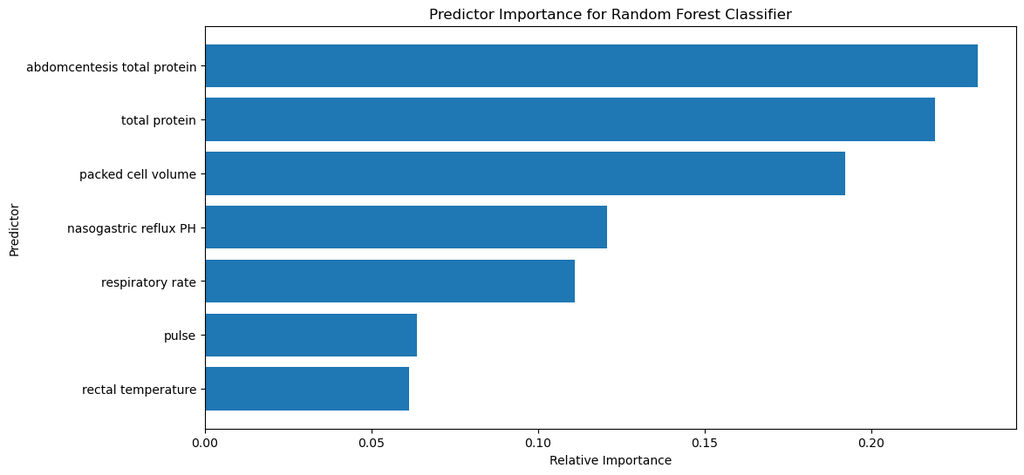

```python
from sklearn.ensemble import RandomForestClassifier
import matplotlib.pyplot as plt
import numpy as np
import pandas as pd
from sklearn.metrics import confusion_matrix, accuracy_score

# Define the number of features (p)
p = X_train_all.shape[1]  # Number of predictors

# Initialize the Random Forest model
model = RandomForestClassifier(max_features=p, random_state=0)

# Fit the model on the training set
forest = model.fit(X_train_all, y_train_all)

# Get and plot the feature importances
importance = np.sort(forest.feature_importances_)

plt.figure(figsize=(12, 6))
plt.barh(X_train_all.columns, importance)
plt.xlabel('Relative Importance')
plt.ylabel('Predictor')
plt.title('Predictor Importance for Random Forest Classifier')
plt.show()
```

```python
# Predict on the test set
y_pred_rf = forest.predict(X_test_all)

# Calculate the confusion matrix
conf_matrix_rf = pd.crosstab(y_test_all, y_pred_rf, rownames=['Actual'], colnames=['Predicted'])
print("Confusion Matrix for Bagging model:")
print(conf_matrix_rf)

# Calculate the misclassification rate
misclassification_rate_rf = np.mean(y_test_all != y_pred_rf)
print(f"Misclassification Rate for Bagging model: {misclassification_rate_rf:.2f}")
```

```
Confusion Matrix for Bagging model:
Predicted  1.0  2.0  3.0
Actual
1.0         29    1    1
2.0         11    5    0
3.0          9    2    2
Misclassification Rate for Bagging model: 0.40
```

v. Repeat the previous part with a random forest.

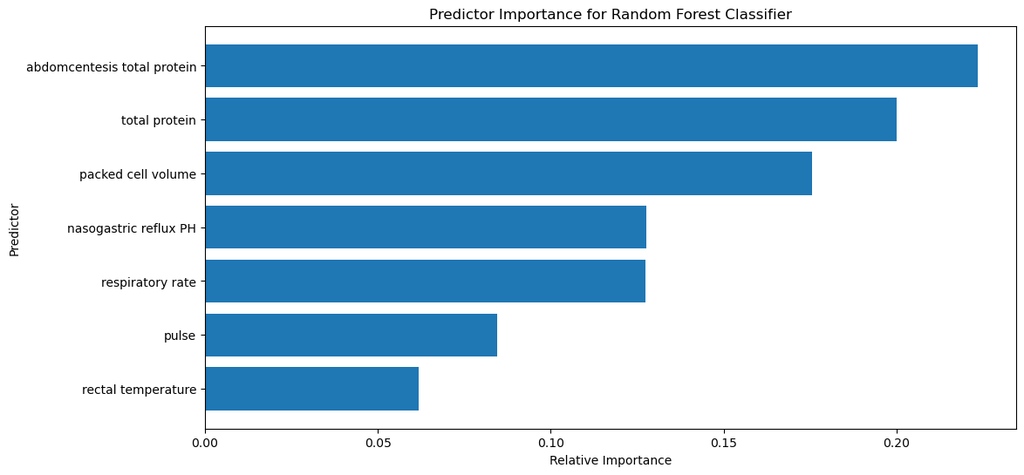

```python
from sklearn.ensemble import RandomForestClassifier
import matplotlib.pyplot as plt
import numpy as np
import pandas as pd
from sklearn.metrics import confusion_matrix, accuracy_score

# Initialize the Random Forest model
rf_model = RandomForestClassifier(random_state=0)

# Fit the model on the training set
random_forest = rf_model.fit(X_train_all, y_train_all)

# Get and plot the feature importances
feature_importances_rf = np.sort(random_forest.feature_importances_)

plt.figure(figsize=(12, 6))
plt.barh(X_train_all.columns, feature_importances_rf)
plt.xlabel('Relative Importance')
plt.ylabel('Predictor')
plt.title('Predictor Importance for Random Forest Classifier')
plt.show()
```

```python
# Predict on the test set
y_pred_rf = rf_model.predict(X_test_all)

# Calculate the confusion matrix
conf_matrix_rf = pd.crosstab(y_test_all, y_pred_rf, rownames=['Actual'], colnames=['Predicted'])
print("Confusion Matrix for Random Forest model:")
print(conf_matrix_rf)

# Calculate the misclassification rate
misclassification_rate_rf = np.mean(y_test_all != y_pred_rf)
print(f"Misclassification Rate for Random Forest model: {misclassification_rate_rf:.2f}")
```

```
Confusion Matrix for Random Forest model:
Predicted  1.0  2.0  3.0
Actual
1.0         30    0    1
2.0         10    6    0
3.0          9    2    2
Misclassification Rate for Random Forest model: 0.37
```

Abdomcentesis total protein, total protein, and packed cell volume appear to be the most important for the classification of the outcome. They are the same predictors that were classified as important in the previous part. The random forest has a lower missclassification rate compared to the previous part (bagging).

vi. Repeat the previous part with the boosting algorithm.

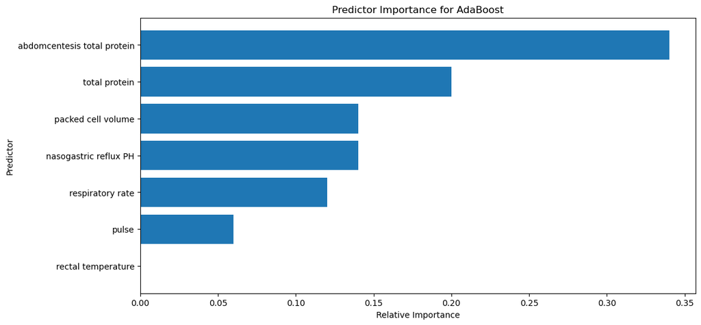

```python
from sklearn.ensemble import AdaBoostClassifier
# Initialize and fit AdaBoost model
ada_boost_model = AdaBoostClassifier(learning_rate=0.1, random_state=0)
ada_boost = ada_boost_model.fit(X_train_all, y_train_all)

# Get and plot feature importances
ada_boost_importance = ada_boost.feature_importances_

plt.figure(figsize=(12, 6))
plt.barh(X_train_all.columns, np.sort(ada_boost_importance))
plt.xlabel('Relative Importance')
plt.ylabel('Predictor')
plt.title('Predictor Importance for AdaBoost')
plt.show()
```

```python
# Predict on the test set
y_pred_ada = ada_boost.predict(X_test_all)

# Calculate the confusion matrix
conf_matrix_ada = pd.crosstab(y_test_all, y_pred_ada, rownames=['Actual'], colnames=['Predicted'])
print("Confusion Matrix for AdaBoost model:")
print(conf_matrix_ada)

# Calculate the misclassification rate
misclassification_rate_ada = np.mean(y_test_all != y_pred_ada)
print(f"Misclassification Rate for AdaBoost model: {misclassification_rate_ada:.2f}")
```

```
Confusion Matrix for AdaBoost model:
Predicted  1.0  2.0
Actual
1.0         29    2
2.0         12    4
3.0         11    2
Misclassification Rate for AdaBoost model: 0.45
```

Problem 2. We are now only interested in classifying horses into alive or dead, i.e. we filter the euthanized horses out of the data set.

i. Fit a support vector classifier on the training set with only pulse and total.protein as predictors. Provide a plot of the estimated decision boundary. Calculate the confusion matrix and the misclassification rate on the test set.

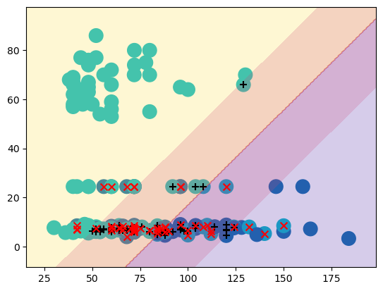

```python
import numpy as np
import matplotlib.pyplot as plt
from sklearn.model_selection import train_test_split
from sklearn.svm import SVC
from ISLP.svm import plot as plot_svm

# Filter data to only include 'alive' and 'dead' outcomes (1 and 2)
filtered_data = data[data['outcome'].isin([1, 2])]
X_svc = filtered_data[['pulse', 'total protein']]
y_svc = filtered_data['outcome']

# Map outcome to binary (1 for 'lived', 0 for 'died')
y_encoded = y_svc.map({1: 1, 2: 0})

# Split the data into training and testing sets
X_train_svc, X_test_svc, y_train_svc, y_test_svc = train_test_split(X_svc, y_encoded, test_size=0.2, random_state=0)

# Reset indices to ensure alignment
X_train_svc = X_train_svc.reset_index(drop=True)
y_train_svc = y_train_svc.reset_index(drop=True)
X_test_svc = X_test_svc.reset_index(drop=True)
y_test_svc = y_test_svc.reset_index(drop=True)

# Fit the SVC model
svc_model = SVC(C=0.01, kernel="linear", random_state=0)
svc_fit = svc_model.fit(X_train_svc, y_train_svc)

# Ensure that X passed to plot_svm has valid feature names
plot_svm(X_train_svc, y_train_svc, svc_fit)
plt.show()
```

```python
# Predict on the test set for the SVC model
y_pred_svc = svc_fit.predict(X_test_svc)

# Calculate the confusion matrix for the SVC model
conf_matrix_svc = pd.crosstab(y_test_svc, y_pred_svc, rownames=['Actual'], colnames=['Predicted'])
print("Confusion Matrix for SVC model:")
print(conf_matrix_svc)

# Calculate the misclassification rate for the SVC model
misclassification_rate_svc = np.mean(y_test_svc != y_pred_svc)
print(f"Misclassification Rate for SVC model: {misclassification_rate_svc:.2f}")
```

```
Confusion Matrix for SVC model:
Predicted  0   1
Actual
0          2  10
1          4  35
Misclassification Rate for SVC model: 0.27
```

The misclassification rate is 0.27.

ii. Fit a support vector classifier on the training set with all available predictors. What form does the decision boundary have? Calculate the confusion matrix and the misclassification rate on the test set. How does this classifier compare against that in the previous part?

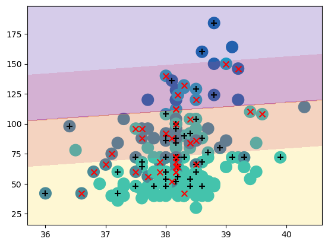

```python
# Prepare the dataset with all available predictors (excluding the outcome column)
X_all = filtered_data.drop(columns=['outcome'])
y_all_encoded = filtered_data['outcome'].map({1: 1, 2: 0})  # Map 'alive' to 1, 'dead' to 0

# Split the data into training and testing sets
X_train_all, X_test_all, y_train_all, y_test_all = train_test_split(X_all, y_all_encoded, test_size=0.2, random_state=0)


# Reset indices to ensure alignment
X_train_all = X_train_all.reset_index(drop=True)
y_train_all = y_train_all.reset_index(drop=True)
X_test_all = X_test_all.reset_index(drop=True)
y_test_all = y_test_all.reset_index(drop=True)


# Fit the SVC model using all predictors
svc_model_all = SVC(C=0.01, kernel="linear", random_state=0)
svc_fit_all = svc_model_all.fit(X_train_all, y_train_all)

# Ensure that X passed to plot_svm has valid feature names
plot_svm(X_train_all, y_train_all, svc_fit_all)
plt.show()
```

```python
# Predict on the test set
y_pred_all = svc_fit_all.predict(X_test_all)

# Calculate the confusion matrix for the SVC model with all predictors
conf_matrix_all = pd.crosstab(y_test_all, y_pred_all, rownames=['Actual'], colnames=['Predicted'])
print("Confusion Matrix for SVC model with all predictors:")
print(conf_matrix_all)

# Calculate the misclassification rate for the SVC model with all predictors
misclassification_rate_all = np.mean(y_test_all != y_pred_all)
print(f"Misclassification Rate for SVC model with all predictors: {misclassification_rate_all:.2f}")
```

```
Confusion Matrix for SVC model with all predictors:
Predicted  0   1
Actual
0          3   9
1          4  35
Misclassification Rate for SVC model with all predictors: 0.25
```

Linear decision boundaries with misclassificatoin rate of 0.25, it is slightly lower than the previous part.

iii. Apply 10-fold cross-validation on the training set to obtain the optimal cost for constraint violations, and fit the optimal support vector classifier on the training set. Calculate the confusion matrix and the misclassification rate on the test set. How does this classifier compare against that in the previous part?

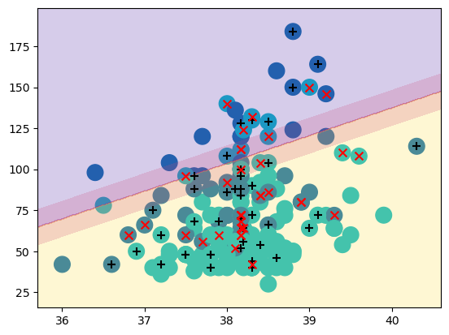

```python
from sklearn.model_selection import KFold
from sklearn.model_selection import GridSearchCV
kfold_svc = KFold(10, shuffle = True, random_state = 0)
grid_svc = GridSearchCV(svc_fit_all, {"C": np.power(10,np.linspace(-3,3,3))}, scoring = "accuracy", refit=True, cv=kfold_svc)
optimal_fit = grid_svc.fit(X_train_all,y_train_all).best_estimator_
plot_svm(X_train_all, y_train_all, optimal_fit)
plt.show()
```

```python
# Predict on the test set and evaluate
cv_svc_prediction = optimal_fit.predict(X_test_all)
conf_matrix = pd.crosstab(y_test_all, cv_svc_prediction, rownames=['Actual'], colnames=['Predicted'])
print("Confusion Matrix:")
print(conf_matrix)

# Calculate the misclassification rate
misclassification_rate = np.mean(y_test_all != cv_svc_prediction)
print(f"Misclassification Rate: {misclassification_rate:.2f}")
```

```
Confusion Matrix:
Predicted  0   1
Actual
0          3   9
1          4  35
Misclassification Rate: 0.25
```

The classifier performs the same, but it produces a much smaller margin.

iv. Fit a support vector machine with a radial kernel on the training set with only pulse and total.protein as predictors. Provide a plot of the estimated decision boundary. Calculate the confusion matrix and the misclassification rate on the test set. How does this SVM compare against the classifier in part i?

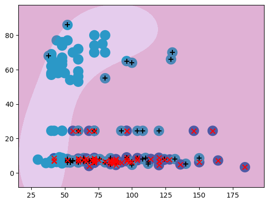

```python
# Filter data to only include 'alive' and 'dead' outcomes (1 and 2)
filtered_data = data[data['outcome'].isin([1, 2])]
X_svc = filtered_data[['pulse', 'total protein']]
y_svc = filtered_data['outcome']

# Map outcome to binary (1 for 'lived', 0 for 'died')
y_encoded = y_svc.map({1: 1, 2: 0})

# Split the data into training and testing sets
X_train_svc, X_test_svc, y_train_svc, y_test_svc = train_test_split(X_svc, y_encoded, test_size=0.2, random_state=0)

# Reset indices to ensure alignment
X_train_svc = X_train_svc.reset_index(drop=True)
y_train_svc = y_train_svc.reset_index(drop=True)
X_test_svc = X_test_svc.reset_index(drop=True)
y_test_svc = y_test_svc.reset_index(drop=True)

# Fit the SVC model
svc_model = SVC(C=0.01, kernel="rbf", random_state=0)
svc_fit = svc_model.fit(X_train_svc, y_train_svc)

# Ensure that X passed to plot_svm has valid feature names
plot_svm(X_train_svc, y_train_svc, svc_fit)
plt.show()
```

```python
# Predict on the test set
y_pred_svc = svc_model.predict(X_test_svc)

# Compute the confusion matrix
conf_matrix = confusion_matrix(y_test_svc, y_pred_svc)
print("Confusion Matrix:\n", conf_matrix)

# Calculate misclassification rate
misclass_rate = 1 - accuracy_score(y_test_svc, y_pred_svc)
print("Misclassification Rate:", misclass_rate)
```

```
Confusion Matrix:
 [[ 0 12]
 [ 0 39]]
Misclassification Rate: 0.23529411764705888
```

This classifier is better than the previous slightly, however its decision boundary is now non-linear.

v. Fit a support vector machine with a radial kernel on the training set with all available predictors. What form does the decision boundary have? Calculate the confusion matrix and the misclassification rate on the test set. How does this SVM compare against that in the previous part?

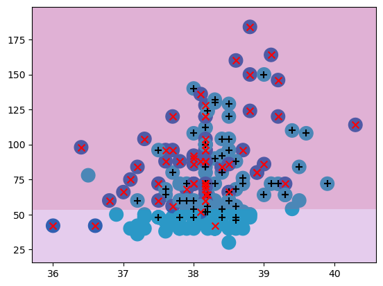

```python
# Filter data to only include 'alive' and 'dead' outcomes (1 and 2)
filtered_data = data[data['outcome'].isin([1, 2])]
X_svc_all = filtered_data.drop(columns='outcome')
y_svc_all = filtered_data['outcome']

# Map outcome to binary (1 for 'lived', 0 for 'died')
y_encoded_all = y_svc.map({1: 1, 2: 0})

# Split the data into training and testing sets
X_train_svc_all, X_test_svc_all, y_train_svc_all, y_test_svc_all = train_test_split(X_svc_all, y_encoded_all, test_size=0.2, random_state=0)

# Reset indices to ensure alignment
X_train_svc_all = X_train_svc_all.reset_index(drop=True)
y_train_svc_all = y_train_svc_all.reset_index(drop=True)
X_test_svc_all = X_test_svc_all.reset_index(drop=True)
y_test_svc_all = y_test_svc_all.reset_index(drop=True)

# Fit the SVC model
svc_model_all = SVC(C=0.01, kernel="rbf", random_state=0)
svc_fit_all = svc_model_all.fit(X_train_svc_all, y_train_svc_all)

# Ensure that X passed to plot_svm has valid feature names
plot_svm(X_train_svc_all, y_train_svc_all, svc_fit_all)
plt.show()
```

```python
# Step 5: Predict on the test set
y_pred_svc_all = svc_model_all.predict(X_test_svc_all)

# Step 6: Compute the confusion matrix
conf_matrix_svc_all = confusion_matrix(y_test_svc_all, y_pred_svc_all)
print("Confusion Matrix:\n", conf_matrix_svc_all)

# Step 7: Calculate misclassification rate
misclass_rate_svc_all = 1 - accuracy_score(y_test_svc_all, y_pred_svc_all)
print("Misclassification Rate:", misclass_rate_svc_all)
```

```
Confusion Matrix:
 [[ 0 12]
 [ 0 39]]
Misclassification Rate: 0.23529411764705888
```

vi. Apply 10-fold cross-validation on the training set to obtain the optimal cost for constraint violations and the optimal kernel parameter γ. Fit the optimal support vector machine on the training set. Calculate the confusion matrix and the misclassification rate on the test set. How does this SVM compare against that in the previous part?

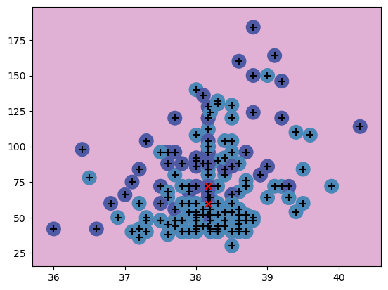

```python
kfold_svc_all = KFold(10,shuffle=True, random_state=0)
grid_svc_all = GridSearchCV(svc_model_all, {"C": np.power(10,np.linspace(-3,3,13)), "gamma":np.power(10,np.linspace(-1,1,11))}, scoring = "accuracy", refit = True, cv=kfold)
optimal_fit_all = grid_svc_all.fit(X_train_svc_all, y_train_svc_all).best_estimator_
plot_svm(X_train_svc_all,y_train_svc_all, optimal_fit_all)
plt.show()
```

```python
# Make predictions on the test set with the optimal model
y_pred_optimal = optimal_fit_all.predict(X_test_svc_all)

# Calculate the confusion matrix
conf_matrix_optimal = confusion_matrix(y_test_svc_all, y_pred_optimal)
print("Confusion Matrix:\n", conf_matrix_optimal)

# Calculate the misclassification rate
misclass_rate_optimal = 1 - accuracy_score(y_test_svc_all, y_pred_optimal)
print("Misclassification Rate:", misclass_rate_optimal)
```

```
Confusion Matrix:
 [[ 2 10]
 [ 0 39]]
Misclassification Rate: 0.196078431372549
```

It has the lowest misclassification rate!